# Index

Oliver Ellis

2023-05-15

# **Using R to investigate changes in perceived corruption in the UK, compared to both Europe and Worldwide**

# Data Origins

Worldwide Corruption Perceptions Index (CPI) data is collected by Transparency International (TI), a non profit organisation aiming to combat global corruption. CPI is an index which attempts to rank included countries by their levels of perceived corruption in their public sector. The use of ‘perceived’ is key - the nature of corruption means that it is typically hidden from public knowledge - only brought to light by public scandals and leaks. This means that the CPI is a measure of the perceived levels of public sector corruption in a country - not the objective levels.

The CPI takes data from 13 different surveys from 12 institutions across the globe, each survey assesses the perspectives of experts and business people on various types of public sector corruption, such as:

- *Bribery*
- *Diversion of Public Funds*
- *Officials using their Public Office for Private Gain without consequence*
- *Ability of governments to contain corruption in the public sector*

This list is not exhaustive, but gives a good snapshot of the types of corruption the CPI includes. However, it is important to note what the CPI measure does not cover:

- *Citizen’s direct perceptions or experience of corruption*
- *Tax Fraud*
- *Illicit Financial Flows*
- *Enablers of corruption*
- *Money laundering*
- *Private Sector Corruption*
- *Informal Economies and Markets*

TI has collated CPI data yearly since 1995, and since 2012 has measured it on a scale of 0-100 where 0 = highly corrupt and 100 = clean. The raw data for this project listed the 179 countries included in the 2022 CPI, alongside their CPI score for every year from 2012 - 2022. This is the most up-to-date data, as CPI is published every January and therefore the 2022 data was published in January 2023.

The data used for this project can be found here: [Corruption Perceptions Index](https://www.transparency.org/en/cpi/2022/)

Data was synthesised from the TI CPI archives into an excel spreadsheet, saved as a csv file, then input into R using read_csv from the tidyverse library, which was installed and loaded at the beginning of the project. This original dataframe was named ‘raw_data’:

```
## # A tibble: 6 × 12
##   Country  `2012` `2013` `2014` `2015` `2016` `2017` `2018` `2019` `2020` `2021`
##   <chr>     <dbl>  <dbl>  <dbl>  <dbl>  <dbl>  <dbl>  <dbl>  <dbl>  <dbl>  <dbl>
## 1 Afghani…      8      8     12     11     15     15     16     16     19     16
## 2 Albania      33     31     33     36     39     38     36     35     36     35
## 3 Algeria      34     36     36     36     34     33     35     35     36     33
## 4 Angola       22     23     19     15     18     19     19     26     27     29
## 5 Argenti…     35     34     37     32     36     39     40     45     42     38
## 6 Armenia      34     36     37     35     33     35     35     42     49     49
## # ℹ 1 more variable: `2022` <dbl>
```

Above is a brief summary of the raw data, showing CPI score per year by Country. This was later cleaned with R to create an entirely new dataframe, which was then used to plot the visualisation.

# Research Questions

I had two main research questions that I aimed to answer with this data visualisation project:

- *How have measures of corruption perception (CPI) changed in the UK over the last ten years?*
- *How does this compare to European and Worldwide averages of perceived corruption?*

# Data Preparation

The first step to do this was to create a World Averages dataframe. I therefore needed to calculate the average of every column 2012 - 2022 and exclude any missing data. Some countries are not included every year, as they must be assessed by at least three different institutional bodies to be included in the CPI, which can result in missing data for some countries in some years.

To do this, I used the colMeans function, and included na.rm(TRUE) to tell R to ignore any missing data points in the calculations. In order for this to work, I also had to tell R that the data was numerical:

```r
worldavg <- colMeans (raw_data[sapply(raw_data, is.numeric)], na.rm = TRUE)
```

This produced a value set called ‘worldavg’ in R, displaying the worldwide average CPI per year, shown below:

```
##     2012     2013     2014     2015     2016     2017
## 43.20231 42.30460 43.30636 42.74251 43.04598 43.12921
```

Next, I needed to repeat this for the European countries only, to calculate the European Average per year. The first step was to filter by a complete list of the European Countries in the original raw_data set, using the filter() function:

```r
europeavg <- filter(raw_data, Country %in% c("Russia",
                                               "Germany",
                                               "UK",
                                               "France",
                                               "Belarus",
                                               "Bulgaria",
                                               "Norway",
                                               "Bosnia and Herzegovina",
                                               "Slovenia",
                                               "Luxembourg",
                                               "Italy",
                                               "Spain",
                                               "Ukraine",
                                               "Poland",
                                               "Austria",
                                               "Denmark",
                                               "Ireland",
                                               "Albania",
                                               "Latvia",
                                               "Malta",
                                               "Romania",
                                               "Netherlands",
                                               "Belgium",
                                               "Czechia",
                                               "Serbia",
                                               "Finland",
                                               "Croatia",
                                               "Lithuania",
                                               "Estonia",
                                               "Iceland",
                                               "Greece",
                                               "Portugal",
                                               "Sweden",
                                               "Hungary",
                                               "Switzerland",
                                               "Slovakia",
                                               "Moldova",
                                               "North Macedonia",
                                               "Montenegro"))
```

This created a value set that was the yearly score for each European country included, as formatted in the raw_data set. I then repeated the steps taken for worldavg, and used the colMeans and na.rm(TRUE) statement again.

This line told R to write over the original filtered europeavg value set with the average score per year for the countries included:

```r
europeavg <- colMeans(europeavg[sapply(europeavg, is.numeric)], na.rm = TRUE)
```

This resulted in creation of a europeavg value set, similar to the worldavg value set created earlier:

```
##     2012     2013     2014     2015     2016     2017
## 58.23077 57.12821 59.10256 60.23077 59.82051 59.79487
```

I then had to convert the worldavg and europeavg value sets to individual dataframes, called Worldavgdata and Europeavgdata, respectively.

I did this using the bind_rows and cbind functions from the dplyr package library, which had been installed and loaded at the beginning of the project.

First, to create dataframe ‘Worldavgdata’:

```r
Worldavgdata <- bind_rows(worldavg)
Worldavgdata <- cbind(Worldavgdata, Country="World Average")
Worldavgdata <- Worldavgdata[, c("Country", names(Worldavgdata)[-which(names(Worldavgdata)=="Country")])]
```

```
##         Country     2012    2013     2014     2015     2016     2017     2018
## 1 World Average 43.20231 42.3046 43.30636 42.74251 43.04598 43.12921 43.17416
##       2019     2020     2021     2022
## 1 43.24157 43.42135 43.47191 43.14525
```

Then, to create dataframe ‘Europeavgdata’:

```r
Europeavgdata <- bind_rows(europeavg)
Europeavgdata <- cbind(Europeavgdata, Country="European Average")
Europeavgdata <- Europeavgdata[, c("Country", names(Europeavgdata)[-which(names(Europeavgdata)=="Country")])]
```

```
##            Country     2012     2013     2014     2015     2016     2017
## 1 European Average 58.23077 57.12821 59.10256 60.23077 59.82051 59.79487
##       2018     2019     2020     2021     2022
## 1 59.71795 59.35897 59.41026 59.48718 59.20513
```

The third variable I wished to plot was the UK score per year. I again used the filter() function to filter out the single row of UK score data from the raw_data dataframe.

```r
uk_score <- filter(raw_data, Country == 'UK')
```

```
## # A tibble: 1 × 12
##   Country `2012` `2013` `2014` `2015` `2016` `2017` `2018` `2019` `2020` `2021`
##   <chr>    <dbl>  <dbl>  <dbl>  <dbl>  <dbl>  <dbl>  <dbl>  <dbl>  <dbl>  <dbl>
## 1 UK          74     76     78     81     81     82     80     77     77     78
## # ℹ 1 more variable: `2022` <dbl>
```

From there, I needed to bind the Worldavgdata, Europeavgdata, and uk_score dataframes into one, long form, dataframe for R to plot.

I first created a dataframe called ‘plotdata’ which contained the bound together Worldavgdata, Europeavgdata, and uk_score dataframes into one. I again used the bind_rows function to accomplish this:

```r
plotdata <- bind_rows(uk_score, Europeavgdata, Worldavgdata)
```

This achieved the need for all three dataframes to be bound as one, however the data was wide form:

```
## # A tibble: 3 × 12
##   Country  `2012` `2013` `2014` `2015` `2016` `2017` `2018` `2019` `2020` `2021`
##   <chr>     <dbl>  <dbl>  <dbl>  <dbl>  <dbl>  <dbl>  <dbl>  <dbl>  <dbl>  <dbl>
## 1 UK         74     76     78     81     81     82     80     77     77     78
## 2 Europea…   58.2   57.1   59.1   60.2   59.8   59.8   59.7   59.4   59.4   59.5
## 3 World A…   43.2   42.3   43.3   42.7   43.0   43.1   43.2   43.2   43.4   43.5
## # ℹ 1 more variable: `2022` <dbl>
```

R prefers to plot long form data, so to convert this dataframe to long form, I used the following code block:

```r
tidyplotdata <- plotdata %>%
  pivot_longer(cols=-c("Country"),
                        names_to = "Year",
                          values_to = "CPI_score")
```

I named the new, long form, dataframe as ‘tidyplotdata’. The wide form ‘plotdata’ dataframe was input using the %>% pipe function from tidyverse for ease.

I then used the pivot_longer function to convert from wide form to long form, splitting the data by Country (UK/Europe Average/World Average), Year (2012 - 2022) and CPI score (0-100). This produced a dataframe like this:

```
## # A tibble: 6 × 3
##   Country Year  CPI_score
##   <chr>   <chr>     <dbl>
## 1 UK      2012         74
## 2 UK      2013         76
## 3 UK      2014         78
## 4 UK      2015         81
## 5 UK      2016         81
## 6 UK      2017         82
```

Which repeated length ways from 2012 - 2022 for UK, World Average, and European Average scores. This format is easier for R to plot onto a visualisation.

# Visualisation

Given that the data is scores over time, it made sense to plot it as a line graph; using the ggplot, geom_path, and geom_point functions from the tidyverse library.

```r
ggplot(tidyplotdata, aes(x = Year, y = CPI_score, colour = Country, group=Country))+ # x/y axis labels and line group
  geom_point(size = 4, alpha = 0.3)+ # dot size and transparency
  geom_path(linewidth = 1)+ # specifies line width
  theme_gray()+ # theme
  labs(title = "Percieved levels of corruption in the UK over time, compared to \n World Average and European Average",
       subtitle = "Plot of Corruption Perception Index (CPI) scores by year 2012 - 2022")+ #labels
  theme (plot.title = element_text(face = "bold"))+ # make title bold
  scale_y_reverse()
```

The ggplot function is telling R what dataset to plot the graph from, in this case I plotted from the ‘tidyplotdata’ dataframe created from the original wide form ‘plotdata’.

Since I plotted a graph with multiple lines, I had to tell R how to separate the data, which was done with the phrase ‘colour = Country, group = Country’ this told R to use a separate colour for each Country’s data, and to connect the data from each Country separately. This produces three separate lines (one for each Country) on the resulting plot, each coloured separately.

##### **Initial graph**

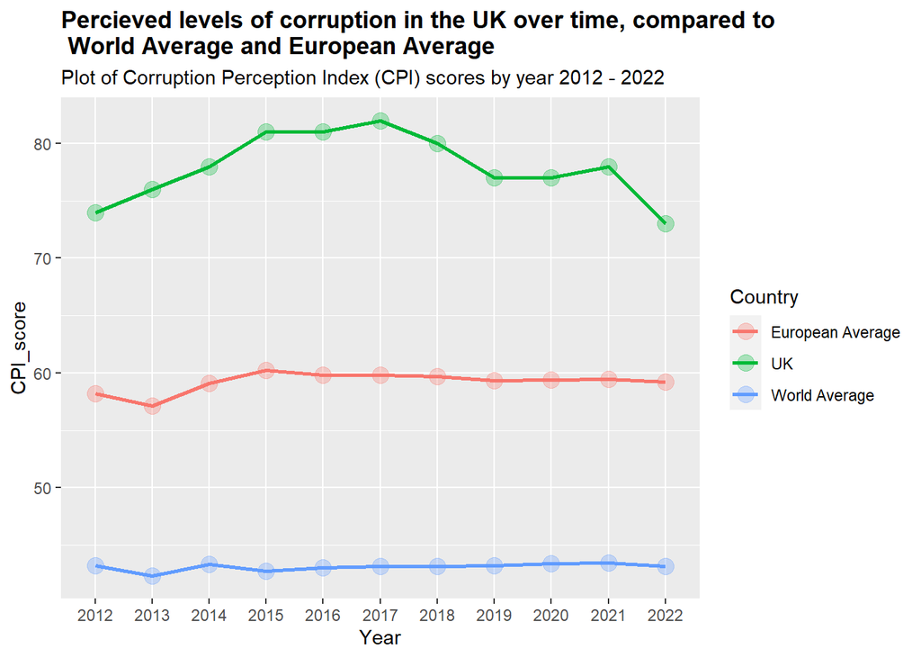

Whilst this plot isn’t inaccurate, it may be misleading to those unfamiliar with the CPI scale, falsely indicating that the UK has higher perceived corruption levels than World and European averages. Including ‘scale_y_reverse’ resolves this issue, sending a much clearer and more readable message to those without prior knowledge:

##### **Final Graph**

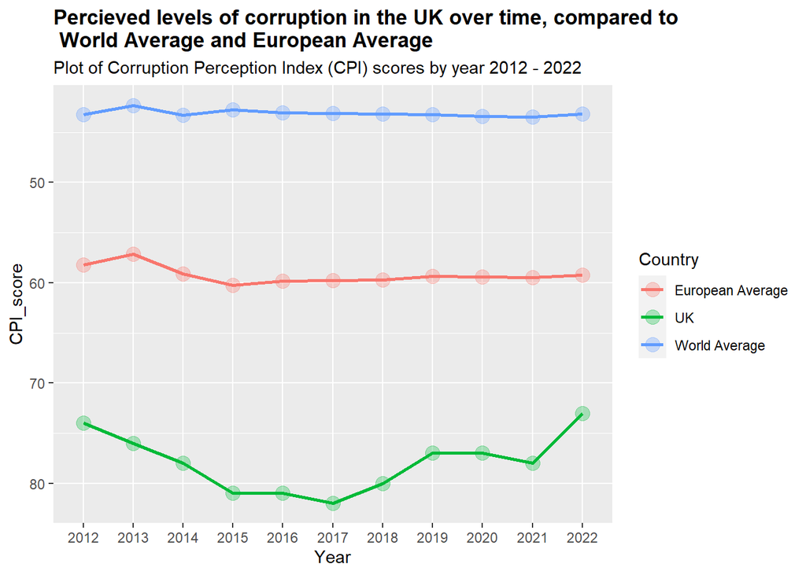

Showing that the UK has significantly lower levels of perceived corruption than both European and World Averages consistently for the last 10 years, but levels of perceived corruption have slowly increased since 2017, getting closer to the European Average.

# Summary

This project has taught me how to use R, the best ways to use it for data visualisation, and how to problem solve/find alternative solutions using my peers and books/web resources when things do not work the way I intended.

If I were to continue or extend this project, I could map how CPI changes with significant public sector events and scandals, such as: elections, wars, recessions, and pandemics. It would be interesting to see whether how these events are reflected in CPI scores over time - especially since TI themselves state that changes in levels of corruption can take a year or two to be reflected in CPI scores.